# HW3

## **Assignment 03 - Text Mining**

November 3, 2023

## **Due Date**

This assignment is due by midnight Pacific Time, November 3rd, 2023.

## **Text Mining**

A new dataset has been added to the data science data repository https://github.com/USCbiostats/data-science-data/tree/master/03_pubmed. The dataset contains 3,241 abstracts from articles collected via 5 PubMed searches. The search terms are listed in the second column, `term` and these will serve as the "documents." Your job is to analyse these abstracts to find interesting insights.

1. Tokenize the abstracts and count the number of each token. Do you see anything interesting? Does removing stop words change what tokens appear as the most frequent? What are the 5 most common tokens for each search term after removing stopwords?

   ```r
   library(data.table)
   library(readr)
   library(dplyr)
   library(tidytext)
   library(tidyr)
   library(stringr)
   library(tm)
   data <- data.table::fread("/Users/vikaskunta/Downloads/pubmed.csv")

   TOKwords <- data %>%
     unnest_tokens(term, abstract)
   wordcount <- TOKwords %>%
     group_by(term) %>%
     summarize(wordcount = n()) %>%
     arrange(desc(wordcount))

   stopwords <- stopwords("en")
   nostopdata <- wordcount %>%
             filter(!(term %in% stopwords))
   ```

   The top 5 are all stop words initially. Once the stop words are removed, the top 5 is different as they are covid, 19, patients, cancer, prostate.
2. Tokenize the abstracts into bigrams. Find the 10 most common bigrams and visualize them with ggplot2.

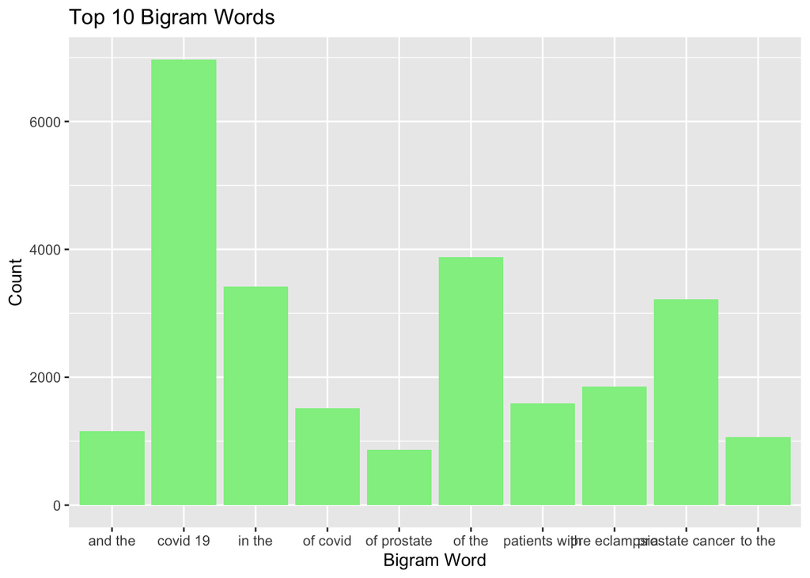

   ```r
   library(ggplot2)
   bigrams <- data %>%
     mutate(abstract = tolower(abstract)) %>%
     unnest_tokens(bigram, abstract, token = "ngrams", n = 2) %>%
     separate(bigram, into = c("word1", "word2"), sep = " ")
   bigramcount <- bigrams %>%
     count(word1, word2, sort = TRUE)
   bigramt10 <- bigramcount %>%
     top_n(10)
   bigramt10$biword <- paste(bigramt10$word1, bigramt10$word2, sep = " ")

   ggplot(bigramt10, aes(x = biword, y = n)) +
        geom_bar(stat = "identity", fill = "lightgreen") +
        labs(x = "Bigram Word", y = "Count") +
        ggtitle("Top 10 Bigram Words")
   ```

   ```r
   bigramt10
   ```

   ```
         word1     word2    n          biword
   1     covid        19 6969        covid 19
   2        of       the 3883          of the
   3        in       the 3418          in the
   4  prostate    cancer 3222 prostate cancer
   5       pre eclampsia 1854   pre eclampsia
   6  patients      with 1587   patients with
   7        of     covid 1519        of covid
   8       and       the 1154         and the
   9        to       the 1061          to the
   10       of  prostate  870     of prostate
   ```

3. Calculate the TF-IDF value for each word-search term combination (here you want the search term to be the "document"). What are the 5 tokens from each search term with the highest TF-IDF value? How are the results different from the answers you got in question 1?

   ```r
   data %>%
     unnest_tokens(abstract, abstract) %>%
     count(abstract, term) %>%
     bind_tf_idf(abstract, term, n) %>%
     arrange(desc(tf_idf))
   ```

   ```
              abstract            term    n           tf      idf     tf_idf
       1:        covid           covid 7275 3.710504e-02 1.609438 0.05971826
       2:     prostate prostate cancer 3832 3.118896e-02 1.609438 0.05019669
       3:    eclampsia    preeclampsia 2005 1.427839e-02 1.609438 0.02298018
       4: preeclampsia    preeclampsia 1863 1.326715e-02 1.609438 0.02135266
       5:   meningitis      meningitis  429 9.194171e-03 1.609438 0.01479745
      ---
   39236:      zealand           covid    6 3.060210e-05 0.000000 0.00000000
   39237:      zealand cystic fibrosis    7 1.424501e-04 0.000000 0.00000000
   39238:      zealand      meningitis    1 2.143163e-05 0.000000 0.00000000
   39239:      zealand    preeclampsia    2 1.424278e-05 0.000000 0.00000000
   39240:      zealand prostate cancer    5 4.069540e-05 0.000000 0.00000000
   ```